# 3_Stan

## Stan code

Next we encode similar models in Stan. We start with the presidents, whom we model by student’s t likelihood. This is a robust version of normal likelihood, because the heavier tails of the t distribution account better for outliers. Moreover, we let the data determine the heaviness of the tails by fitting the shape parameter nu on the data (in classical stats this parameter is called df - degrees of freedom)

model:

$$y_i \sim student(\nu, \mu, \sigma)$$
$$\nu \sim student(2, 1, 50)$$
$$\mu \sim normal(180, 10)$$
$$\sigma \sim student(4, 0, 5)$$

**ülesanne - kirjutage see mudel ümber nii, et see kasutaks normaaljaotuse tõepära ja normaaljaotuse prioreid, kusjuures tehke sigma prior vähem informatiivseks.**

```r
modelString <- "

data {
  int<lower=0> N; //the nr of data points
  vector[N] heights; //a vector of N datapoints called heights.
}
parameters {
  real<lower=1> nu; //shape parameter cannot be <1
  real mu; //mean
  real<lower=0> sigma; //standard deviation
}
model {
  nu ~ student_t(2, 1, 50); //prior for shape parameter
  mu ~ normal(180, 10); //prior for the mean
  sigma ~ student_t(4, 0, 5); //prior for the SD
  heights ~ student_t(nu, mu, sigma); //regression model
}

"
stanDso <- stan_model(model_code = modelString)

heights <- tibble(value = c(183, 192, 182, 183, 177, 185, 188, 188, 182, 185, 188))

dataList <- list(heights = heights$value,
                 N = length(heights$value))

fit1 <- sampling(object = stanDso, data = dataList,
    chains = 3, cores=3, iter = 1000, warmup = 200, thin = 1)

write_rds(fit1, "models/fit1.rds")
```

```
ci_level: 0.8 (80% intervals)
outer_level: 0.95 (95% intervals)
```

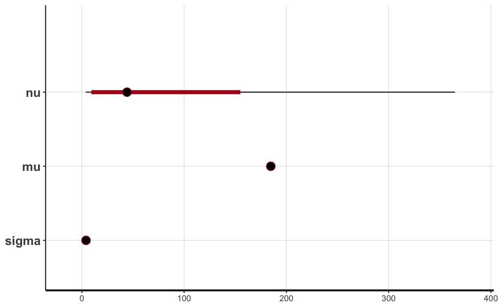

```r
fit1 <- read_rds("models/fit1.rds")
plot(fit1)
```

```r
fit1 %>% tidy()
```

| term | estimate | std.error |
| --- | --- | --- |
| nu | 83.219781 | 223.161546 |
| mu | 184.707282 | 1.355640 |
| sigma | 4.264102 | 1.146698 |

```r
fit1
```

```
Inference for Stan model: df64bdb04a46456ae5e57c45f44b989e.
3 chains, each with iter=1000; warmup=200; thin=1;
post-warmup draws per chain=800, total post-warmup draws=2400.

        mean se_mean     sd   2.5%    25%    50%    75%  97.5% n_eff Rhat
nu     83.22    5.51 223.16   3.75  20.77  44.23  85.62 366.07  1640    1
mu    184.71    0.04   1.36 181.97 183.87 184.72 185.51 187.42  1383    1
sigma   4.26    0.03   1.15   2.58   3.51   4.06   4.82   6.94  1873    1
lp__  -21.83    0.05   1.47 -25.72 -22.50 -21.44 -20.80 -20.21   921    1

Samples were drawn using NUTS(diag_e) at Tue Aug  4 17:58:15 2020.
For each parameter, n_eff is a crude measure of effective sample size,
and Rhat is the potential scale reduction factor on split chains (at
convergence, Rhat=1).
```

markov chains

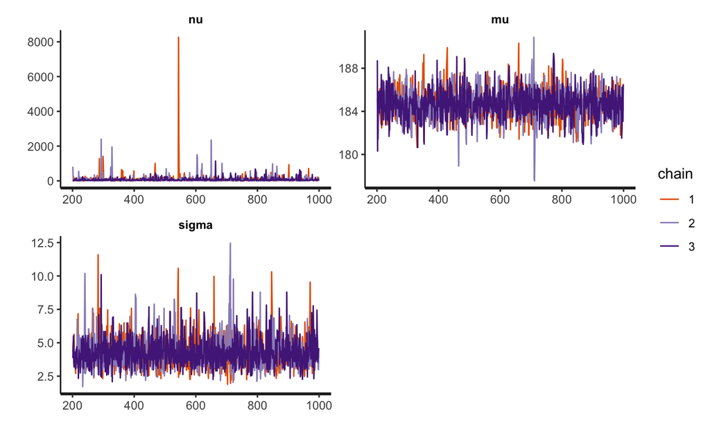

```r
traceplot(fit1, nrow=2)
```

posteriors:

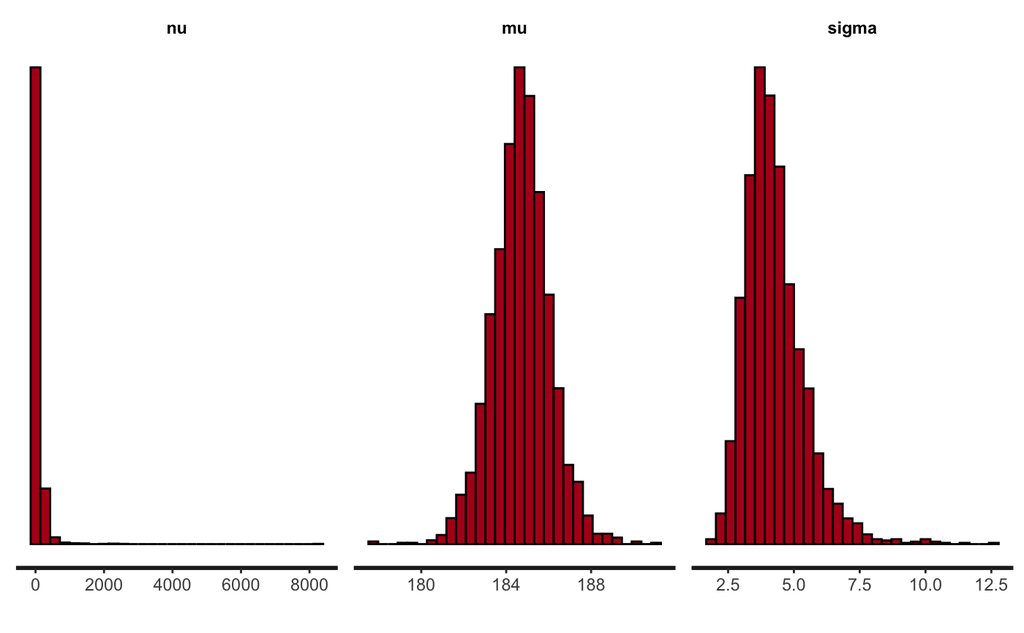

```r
#plot(fit1, plotfun = "hist")
stan_hist(fit1)
```

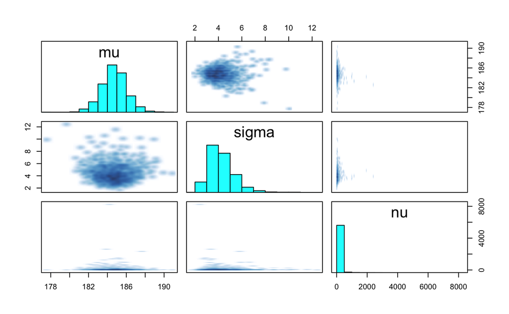

```r
pairs(fit1, pars= c("mu", "sigma", "nu"))
```

posteerior samples

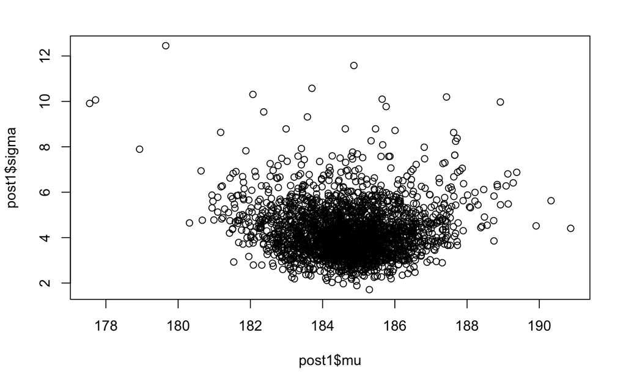

```r
post1 <- as.data.frame(fit1)
plot(post1$mu, post1$sigma)
```

```r
pres_brms <- brm(value~1, data= heights, family = student())
write_rds(pres_brms, "models/pres_brms")
```

```r
tidy(pres_brms)
```

| term | estimate | std.error | lower | upper |
| --- | --- | --- | --- | --- |
| b_Intercept | 184.811496 | 1.447901 | 182.461040 | 187.140324 |
| sigma | 4.350663 | 1.214018 | 2.777434 | 6.537025 |
| nu | 20.378918 | 13.723315 | 4.539076 | 47.855902 |
| lp__ | -37.590361 | 1.377186 | -40.288812 | -36.106543 |

**excersise – run the same for normal likelihood**

## expand this into regression

We simulate data:

```r
set.seed(12)
data <- tibble(value = c(rnorm(n=8, mean=100, sd=10), rnorm(8, 150, 15)),
               indeks=rep(c(0, 1), each=8))
```

```r
t.test(data=data, value~indeks)
```

```
    Welch Two Sample t-test

data:  value by indeks
t = -10.449, df = 13.276, p-value = 8.89e-08
alternative hypothesis: true difference in means is not equal to 0
95 percent confidence interval:
 -60.21584 -39.61759
sample estimates:
mean in group 0 mean in group 1
       93.75789       143.67460
```

```r
lm(data=data, value~indeks)
```

```
Call:
lm(formula = value ~ indeks, data = data)

Coefficients:
(Intercept)       indeks
      93.76        49.92
```

```r
modelString <- "

data {
  int<lower=0> N;
  vector[N] y;
  vector[N] x;
}
parameters {
  real<lower=1> nu;
  real<lower=0> alpha;
  real beta;
  real<lower=0> sigma;
}
model {
  nu ~ student_t(4, 2, 30); //prior for shape parameter
  alpha ~ normal(100, 50); //prior for the mean
  beta ~ normal(50, 50);
  sigma ~ student_t(4, 0, 20); //prior for the SD
    y ~ student_t(nu, alpha + beta * x, sigma);
}

"
stanDso <- stan_model(model_code = modelString)

dataList <- list(y = data$value,
                 x = data$indeks,
                 N = nrow(data))

fit2 <- sampling(object = stanDso, data = dataList,
    chains = 3, cores=3, iter = 1000, warmup = 400, thin = 1)

write_rds(fit2, "models/fit2.rds")
```

```r
fit2 <- read_rds("models/fit2.rds")
fit2
```

```
Inference for Stan model: da9c5cf4c8c4dcd7b2ad28f7c999ddec.
3 chains, each with iter=1000; warmup=400; thin=1;
post-warmup draws per chain=600, total post-warmup draws=1800.

        mean se_mean    sd   2.5%    25%    50%    75%  97.5% n_eff Rhat
nu     34.12    0.99 33.42   3.06  12.91  25.55  44.09 116.01  1146    1
alpha  93.46    0.13  3.79  86.17  90.92  93.43  95.91 100.87   831    1
beta   50.33    0.18  5.37  39.33  47.07  50.29  53.72  61.26   865    1
sigma   9.72    0.06  2.11   6.31   8.20   9.49  10.89  14.49  1126    1
lp__  -41.35    0.06  1.62 -45.57 -42.12 -41.01 -40.15 -39.36   718    1

Samples were drawn using NUTS(diag_e) at Tue Aug  4 18:50:47 2020.
For each parameter, n_eff is a crude measure of effective sample size,
and Rhat is the potential scale reduction factor on split chains (at
convergence, Rhat=1).
```

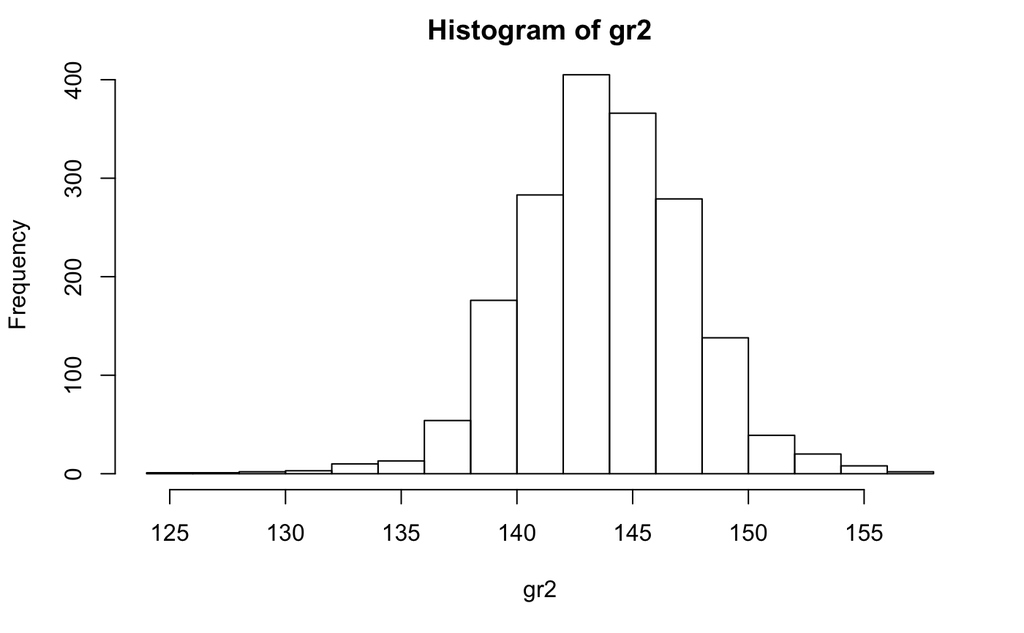

```r
post2 <- as.data.frame(fit2)
gr2 <- post2$alpha + post2$beta
hist(gr2)
```

```
ci_level: 0.8 (80% intervals)
outer_level: 0.95 (95% intervals)
```

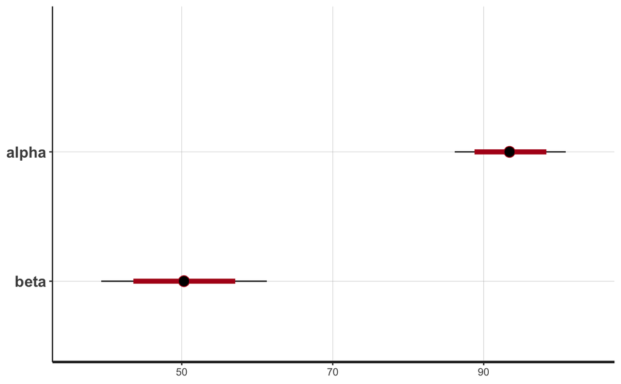

```r
plot(fit2, pars=c("alpha", "beta"))
```

```r
get_prior(data=data, bf(value~indeks, sigma~indeks), family = student)
```

|  | prior | class | coef | group | resp | dpar | nlpar | bound |
| --- | --- | --- | --- | --- | --- | --- | --- | --- |
| 1 |  | b |  |  |  |  |  |  |
| 2 |  | b | indeks |  |  |  |  |  |
| 3 | student_t(3, 123, 39) | Intercept |  |  |  |  |  |  |
| 4 | gamma(2, 0.1) | nu |  |  |  |  |  |  |
| 5 |  | b |  |  |  | sigma |  |  |
| 6 |  | b | indeks |  |  | sigma |  |  |
| 7 | student_t(3, 0, 10) | Intercept |  |  |  | sigma |  |  |

```r
data1 <- data
data1$indeks <- as.character(data1$indeks)
```

```r
fit3 <- brm(data=data1, value~indeks, family = student,
            prior = c(prior(student_t(4,2,30), class=nu),
                      prior(normal(100, 50), class=Intercept),
                      prior(normal(50, 50), class=b),
                      prior(student_t(4,0,20), class=sigma)),
            cores=3, chains = 3)
write_rds(fit3, "models/fit3.rds")
```

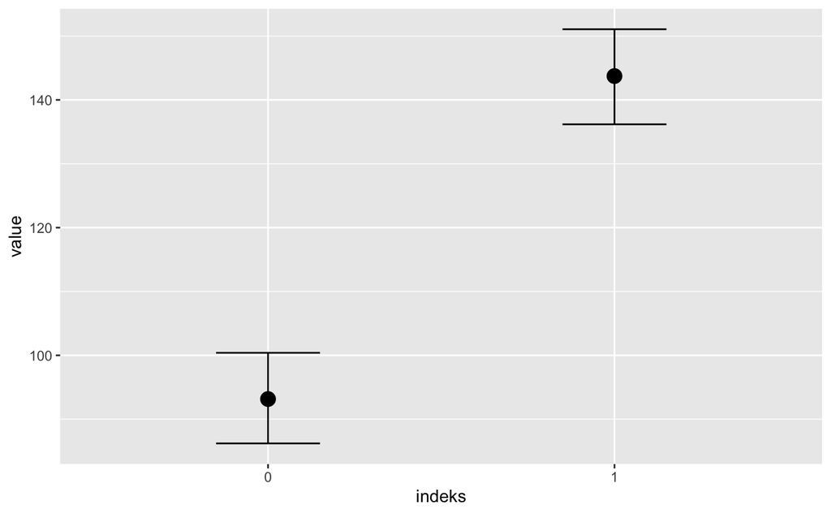

```r
fit3 <- read_rds("models/fit3.rds")
conditional_effects(fit3)
```

```r
fit4 <- brm(data=data1, bf(value~indeks, sigma~indeks), family = student,

            cores=3, chains = 3)
write_rds(fit4, "models/fit4.rds")
```

```r
(fit4 <- read_rds("models/fit4.rds"))
```

```
 Family: student
  Links: mu = identity; sigma = log; nu = identity
Formula: value ~ indeks
         sigma ~ indeks
   Data: data1 (Number of observations: 16)
Samples: 3 chains, each with iter = 2000; warmup = 1000; thin = 1;
         total post-warmup samples = 3000

Population-Level Effects:
                Estimate Est.Error l-95% CI u-95% CI Rhat Bulk_ESS Tail_ESS
Intercept          93.20      4.20    84.91   101.66 1.00     2071     1376
sigma_Intercept     2.30      0.34     1.63     3.02 1.00     2065     1317
indeks1            50.47      5.67    39.04    61.89 1.00     1998     1595
sigma_indeks1      -0.15      0.45    -1.02     0.79 1.00     2129     2043

Family Specific Parameters:
   Estimate Est.Error l-95% CI u-95% CI Rhat Bulk_ESS Tail_ESS
nu    19.51     13.70     2.91    55.80 1.00     2094     1206

Samples were drawn using sampling(NUTS). For each parameter, Bulk_ESS
and Tail_ESS are effective sample size measures, and Rhat is the potential
scale reduction factor on split chains (at convergence, Rhat = 1).
```

```r
exp(2.31)
```

```
[1] 10.07442
```

```r
exp(-0.17+2.31)
```

```
[1] 8.499438
```

```r
data1 %>% group_by(indeks) %>% summarise(SD = sd(value))
```

| indeks | SD |
| --- | --- |
| 0 | 10.612031 |
| 1 | 8.364853 |

```r
t.test(data=data1, value~indeks)
```

```
    Welch Two Sample t-test

data:  value by indeks
t = -10.449, df = 13.276, p-value = 8.89e-08
alternative hypothesis: true difference in means is not equal to 0
95 percent confidence interval:
 -60.21584 -39.61759
sample estimates:
mean in group 0 mean in group 1
       93.75789       143.67460
```

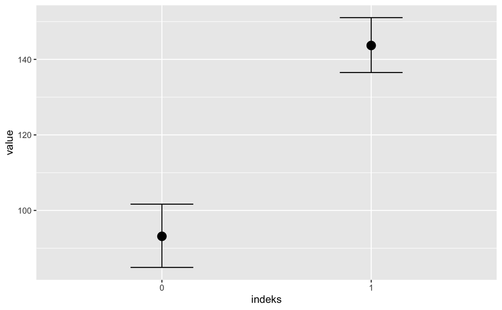

```r
conditional_effects(fit4)
```

### model the proportion via binomial distribution

Here we have a covid-19 antibody study of 3330 americans, of whom 50 tested positive. Remember, p is the single parameter in this model.

raw ratio:

```r
50/3330
```

```
[1] 0.01501502
```

or 1.5%

```r
modelString <- "

data {
  int<lower = 0> y;
  int<lower = 0> n;
}
parameters {
  real<lower=0, upper = 1> p;
}
model {
  p ~ beta(1,1);
  y ~ binomial(n, p);
}

"
stanDso2 <- stan_model(model_code = modelString)

y <- 50
n <- 3330

dataList <- list(y = y,
                 n = n)

stanFit3 <- sampling(object = stanDso2, data = dataList,
    chains = 3, cores=3, iter = 1000, warmup = 200, thin = 1)

write_rds(stanFit3, "models/stanFit3.rds")
```

```r
mudel1 <- brm(success|trials(3330)~1, data = list(success=50), family=binomial)
write_rds(mudel1, "models/mudel1.rds")
```

```r
mudel1 <- read_rds("models/mudel1.rds")
mudel1_p <- posterior_samples(mudel1)
hist(inv_logit_scaled(mudel1_p$b_Intercept))
```

[output not shown]

## võtame arvesse testi sensitiivsuse ja spetsiifilisuse

Seda määrati uuringu käigus eraldi, kasutades inimesi, kes konkreetseid proove võtsid ja analüüsisid

```r
50/3330 * 103/122 + (1 - 50/3330) * (1 - 399/401)
```

[output not shown]

ehk 1.8%

siin jätan priori defineerimata - Stan teeb selle tasaseks prioriks.

```r
modelString <- "data {
  int<lower = 0> y_sample;
  int<lower = 0> n_sample;
  real<lower = 0, upper = 1> spec;
  real<lower = 0, upper = 1> sens;
}
parameters {
  real<lower=0, upper = 1> p;
}
model {
  real p_sample = p * sens + (1 - p) * (1 - spec);
  y_sample ~ binomial(n_sample, p_sample);
}"

stanDso3 <- stan_model(model_code = modelString)

y_sample <- 50
n_sample <- 3330
spec <- 399/401
sens <- 103/122

dataList <- list(y_sample = y_sample,
                 n_sample = n_sample,
                 spec = spec,
                 sens = sens)

stanFit3 <- sampling(object = stanDso3, data = dataList,
    chains = 3, cores=3, iter = 1000, warmup = 200, thin = 1)
write_rds(stanFit3, "models/stanFit3.rds")
```

```r
stanFit3 <- read_rds("models/stanFit3.rds")
tidy(stanFit3)
```

| term | estimate | std.error |
| --- | --- | --- |
| p | 0.01217221 | 0.002638665 |

```
`expand_scale()` is deprecated; use `expansion()` instead.
```

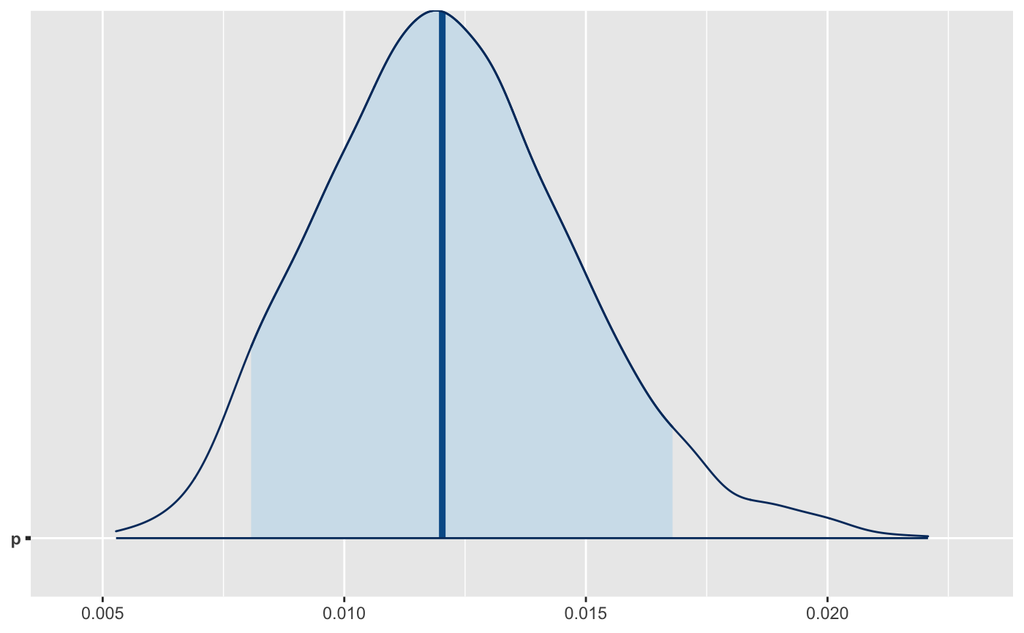

```r
mcmc_areas(stanFit3, pars = c("p"), prob = 0.9)
```

```r
modelString <- "data {
  int<lower = 0> y_sample;
  int<lower = 0> n_sample;
  int<lower = 0> y_spec;
  int<lower = 0> n_spec;
  int<lower = 0> y_sens;
  int<lower = 0> n_sens;
}
parameters {
  real<lower=0, upper = 1> p;
  real<lower=0, upper = 1> spec;
  real<lower=0, upper = 1> sens;
}
model {
  real p_sample = p * sens + (1 - p) * (1 - spec);
  y_sample ~ binomial(n_sample, p_sample);
  y_spec ~ binomial(n_spec, spec);
  y_sens ~ binomial(n_sens, sens);
}"

stanDso4 <- stan_model(model_code = modelString)

y_sample <- 50
n_sample <- 3330
y_spec <- 399
n_spec <- 401
y_sens <- 103
n_sens <- 122

dataList <- list(y_sample = y_sample,
                 n_sample = n_sample,
                 y_spec = y_spec,
                 n_spec = n_spec,
                 y_sens = y_sens,
                 n_sens = n_sens)

stanFit4 <- sampling(object = stanDso4, data = dataList,
    chains = 3, cores=3, iter = 1000, warmup = 200, thin = 1)

write_rds(stanFit4, "models/stanFit4.rds")
```

```r
stanFit4 <- read_rds("models/stanFit4.rds")
tidy(stanFit4)
```

| term | estimate | std.error |
| --- | --- | --- |
| p | 0.01025031 | 0.004715399 |
| spec | 0.99313735 | 0.003498413 |
| sens | 0.83828447 | 0.032756221 |

lets slap some priors on p, sens and spec. Especially for p I’m putting a strong prior that says that most likely incidence is 1% and incidences over 3% are very unlikely. I am vaguer for sensitivity and specificity where the prior has heavy tails allowing for a wide range of possibilities.

```r
modelString <- "data {
  int<lower = 0> y_sample;
  int<lower = 0> n_sample;
  int<lower = 0> y_spec;
  int<lower = 0> n_spec;
  int<lower = 0> y_sens;
  int<lower = 0> n_sens;
}
parameters {
  real<lower=0, upper = 1> p;
  real<lower=0, upper = 1> spec;
  real<lower=0, upper = 1> sens;
}
model {
  real p_sample = p * sens + (1 - p) * (1 - spec);
  p ~ normal(0.01, 0.01);
  spec ~ student_t(6, 0.9, 0.1);
  sens ~ student_t(3, 0.8, 0.1);
  y_sample ~ binomial(n_sample, p_sample);
  y_spec ~ binomial(n_spec, spec);
  y_sens ~ binomial(n_sens, sens);
}"

stanDso5 <- stan_model(model_code = modelString)

y_sample <- 50
n_sample <- 3330
y_spec <- 399
n_spec <- 401
y_sens <- 103
n_sens <- 122

dataList <- list(y_sample = y_sample,
                 n_sample = n_sample,
                 y_spec = y_spec,
                 n_spec = n_spec,
                 y_sens = y_sens,
                 n_sens = n_sens)

stanFit5 <- sampling(object = stanDso5, data = dataList,
    chains = 3, cores=3, iter = 1000, warmup = 300, thin = 1)
write_rds(stanFit5, "models/stanFit5.rds")
```

```r
stanFit5 <- read_rds("models/stanFit5.rds")
tidy(stanFit5)
```

| term | estimate | std.error |
| --- | --- | --- |
| p | 0.01059813 | 0.004201813 |
| spec | 0.99338560 | 0.003211204 |
| sens | 0.83345742 | 0.033774996 |

```r
0.01059813 - 1.96*0.004201813
```

```
[1] 0.002362577
```

lower bound for the p is about 0.2% incidence

higher bound is about 1.9%

```r
0.01059813 + 1.96*0.004201813
```

```
[1] 0.01883368
```

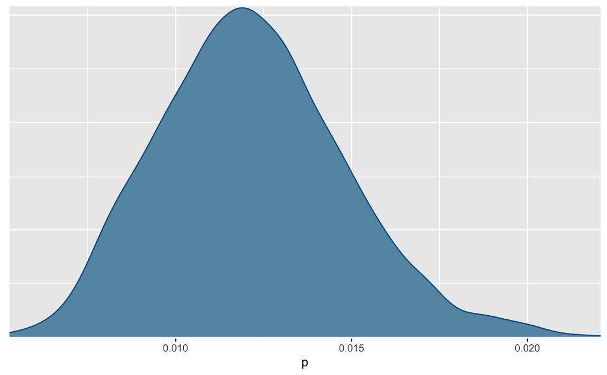

```r
mcmc_dens(stanFit3, pars = c("p"))
```

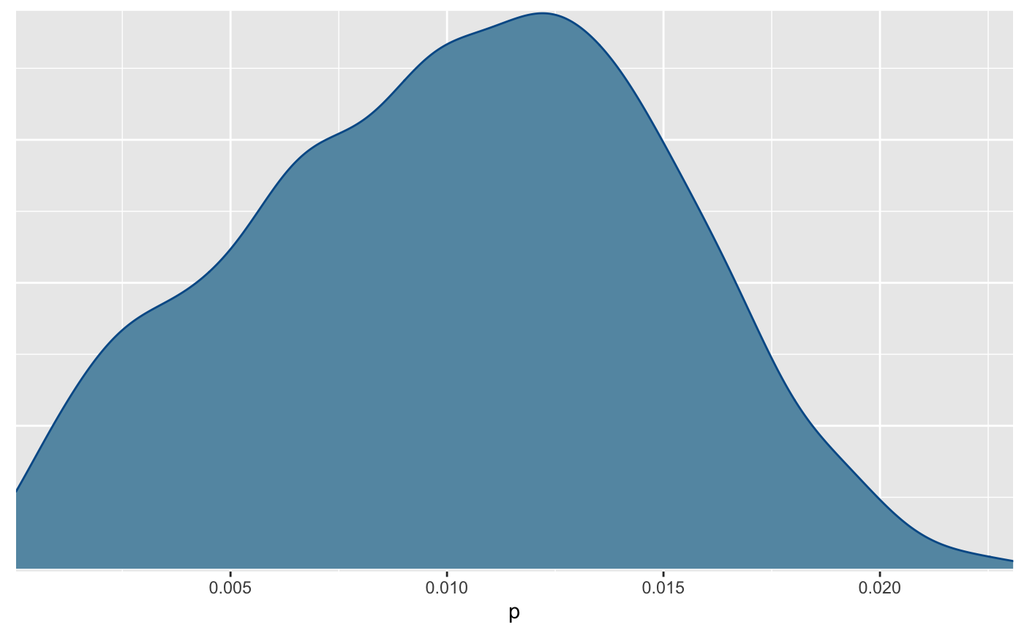

```r
mcmc_dens(stanFit4, pars = c("p"))
```

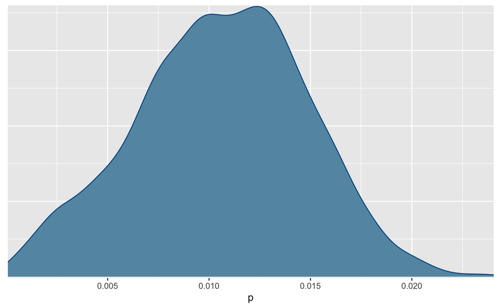

```r
mcmc_dens(stanFit5, pars = c("p"))
```